# Super Kart Sales Prediction

## **Context:**

A sales forecast is a prediction of future sales revenue based on historical data, industry trends, and the status of the current sales pipeline. Businesses use the sales forecast to estimate weekly, monthly, quarterly, and annual sales totals. It is extremely important for a company to make an accurate sales forecast as it adds value across an organization and helps the different verticals to chalk out their future course of action. Forecasting helps an organization plan its sales operations by region and provides valuable insights to the supply chain team regarding the procurement of goods and materials. An accurate sales forecast process has many benefits which include improved decision-making about the future and reduction of sales pipeline and forecast risks. Moreover, it helps to reduce the time spent in planning territory coverage and establish benchmarks that can be used to assess trends in the future.

## **Objective:**

SuperKart is an organization that owns a chain of supermarkets and food marts providing a wide range of products. They want to predict the future sales revenue of its different outlets so that they can strategize their sales operation across different tier cities and plan their inventory accordingly. To achieve this purpose, SuperKart has hired a data science firm, shared the sales records of its various outlets for the previous quarter, and asked the firm to come up with a suitable model to predict the total sales of the stores for the upcoming quarter.

## **Data Description:**

The data contains the different attributes of the various products and stores. The detailed data dictionary is given below.

- Product_Id - unique identifier of each product, each identifier having two letters at the beginning followed by a number.
- Product_Weight - the weight of each product
- Product_Sugar_Content - sugar content of each product like low sugar, regular, and no sugar
- Product_Allocated_Area - the ratio of the allocated display area of each product to the total display area of all the products in a store
- Product_Type - broad category for each product like meat, snack foods, hard drinks, dairy, canned, soft drinks, health and hygiene, baking goods, bread, breakfast, frozen foods, fruits and vegetables, household, seafood, starchy foods, others
- Product_MRP - maximum retail price of each product
- Store_Id - unique identifier of each store
- Store_Establishment_Year - the year in which the store was established
- Store_Size - the size of the store depending on sq. feet like high, medium, and low
- Store_Location_City_Type - the type of city in which the store is located like Tier 1, Tier 2, and Tier 3. Tier 1 consists of cities where the standard of living is comparatively higher than its Tier 2 and Tier 3 counterparts.
- Store_Type - the type of store depending on the products that are being sold there like Departmental Store, Supermarket Type 1, Supermarket Type 2, and Food Mart
- Product_Store_Sales_Total - total revenue generated by the sale of that particular product in that particular store

### **Connecting to Google Drive and Importing Libraries**

```python
# connect to google drive to read dataset
from google.colab import drive
drive.mount('/content/drive')
```

```python
# Libraries to help with data reading and manipulation
import numpy as np
import pandas as pd

# Libraries for data vizualization
import matplotlib.pyplot as plt
import seaborn as sns
import matplotlib.patches as patches

# Library to split the data
from sklearn.model_selection import train_test_split

# Libraries for linear regression models
import statsmodels.api as sm
from statsmodels.formula.api import ols
from sklearn.linear_model import LinearRegression

# Library for data preparation
from sklearn.model_selection import train_test_split

# Removes the limit for number of displayed columns
pd.set_option('display.max_columns', None)

# Removes the limit for number of displayed rows
pd.set_option('display.max_rows', 100)

# To supress warnings
import warnings
warnings.filterwarnings('ignore')

# Stats models api
import statsmodels.stats.api as sms
```

### **Importing the Dataset**

```python
kart = pd.read_csv('/content/drive/MyDrive/Colab Notebooks/Super Kart/SuperKart.csv')
```

```python
# Creating copy of the original data set
data = kart.copy()
```

### **Inspecting the Dataset**

```python
data.head()
```

|  | Product_Id | Product_Weight | Product_Sugar_Content | Product_Allocated_Area | Product_Type | Product_MRP | Store_Id | Store_Establishment_Year | Store_Size | Store_Location_City_Type | Store_Type | Product_Store_Sales_Total |
| --- | --- | --- | --- | --- | --- | --- | --- | --- | --- | --- | --- | --- |
| 0 | FD6114 | 12.66 | Low Sugar | 0.027 | Frozen Foods | 117.08 | OUT004 | 2009 | Medium | Tier 2 | Supermarket Type2 | 2842.40 |
| 1 | FD7839 | 16.54 | Low Sugar | 0.144 | Dairy | 171.43 | OUT003 | 1999 | Medium | Tier 1 | Departmental Store | 4830.02 |
| 2 | FD5075 | 14.28 | Regular | 0.031 | Canned | 162.08 | OUT001 | 1987 | High | Tier 2 | Supermarket Type1 | 4130.16 |
| 3 | FD8233 | 12.10 | Low Sugar | 0.112 | Baking Goods | 186.31 | OUT001 | 1987 | High | Tier 2 | Supermarket Type1 | 4132.18 |
| 4 | NC1180 | 9.57 | No Sugar | 0.010 | Health and Hygiene | 123.67 | OUT002 | 1998 | Small | Tier 3 | Food Mart | 2279.36 |

```python
data.tail()
```

|  | Product_Id | Product_Weight | Product_Sugar_Content | Product_Allocated_Area | Product_Type | Product_MRP | Store_Id | Store_Establishment_Year | Store_Size | Store_Location_City_Type | Store_Type | Product_Store_Sales_Total |
| --- | --- | --- | --- | --- | --- | --- | --- | --- | --- | --- | --- | --- |
| 8758 | NC7546 | 14.80 | No Sugar | 0.016 | Health and Hygiene | 140.53 | OUT004 | 2009 | Medium | Tier 2 | Supermarket Type2 | 3806.53 |
| 8759 | NC584 | 14.06 | No Sugar | 0.142 | Household | 144.51 | OUT004 | 2009 | Medium | Tier 2 | Supermarket Type2 | 5020.74 |
| 8760 | NC2471 | 13.48 | No Sugar | 0.017 | Health and Hygiene | 88.58 | OUT001 | 1987 | High | Tier 2 | Supermarket Type1 | 2443.42 |
| 8761 | NC7187 | 13.89 | No Sugar | 0.193 | Household | 168.44 | OUT001 | 1987 | High | Tier 2 | Supermarket Type1 | 4171.82 |
| 8762 | FD306 | 14.73 | Low Sugar | 0.177 | Snack Foods | 224.93 | OUT002 | 1998 | Small | Tier 3 | Food Mart | 2186.08 |

**Observations:**

- The variable Product_Store_Sales_Total gives us the total sales of each product per store and will be our target variable which we are going to predict.
- The remaining variables are independent variables of which we will base our predictions off of.

### **Understanding the dataset shape, types and missing values**

```python
data.shape
```

```
(8763, 12)
```

```python
data.info()
```

```
<class 'pandas.core.frame.DataFrame'>
RangeIndex: 8763 entries, 0 to 8762
Data columns (total 12 columns):
 #   Column                     Non-Null Count  Dtype
---  ------                     --------------  -----
 0   Product_Id                 8763 non-null   object
 1   Product_Weight             8763 non-null   float64
 2   Product_Sugar_Content      8763 non-null   object
 3   Product_Allocated_Area     8763 non-null   float64
 4   Product_Type               8763 non-null   object
 5   Product_MRP                8763 non-null   float64
 6   Store_Id                   8763 non-null   object
 7   Store_Establishment_Year   8763 non-null   int64
 8   Store_Size                 8763 non-null   object
 9   Store_Location_City_Type   8763 non-null   object
 10  Store_Type                 8763 non-null   object
 11  Product_Store_Sales_Total  8763 non-null   float64
dtypes: float64(4), int64(1), object(7)
memory usage: 821.7+ KB
```

**Observations**

- There are 12 columns (variables) in the dataset and 8763 rows (different products)
- Product_Weight, Product_Allocated_Area, Product_MRP, Store_Establistment_Year, and Product_Store_Sales_Total are all numeric columns. The remaining are object type. The object type variables will require further manipulation to be used in our predictions.
- There are 8763 non-null observations for each column, meaning that there shouldn't be any missing values in the dataset.

```python
# Checking for missing values
data.isnull().sum()
```

```
Product_Id                   0
Product_Weight               0
Product_Sugar_Content        0
Product_Allocated_Area       0
Product_Type                 0
Product_MRP                  0
Store_Id                     0
Store_Establishment_Year     0
Store_Size                   0
Store_Location_City_Type     0
Store_Type                   0
Product_Store_Sales_Total    0
dtype: int64
```

**Observation**

- We have been able to double check and confirm that there are no missing values.

```python
# Checking for duplicate values
data.duplicated().sum()
```

```
0
```

**Observations:**

- There are no missing values in the data.

# **Exploratory Data Analysis**

## **Surface Level Exploration of Individual Variables**

```python
# Checking the statistical summary of the data
data.describe(include = 'all').T
```

|  | count | unique | top | freq | mean | std | min | 25% | 50% | 75% | max |
| --- | --- | --- | --- | --- | --- | --- | --- | --- | --- | --- | --- |
| Product_Id | 8763 | 8763 | FD6114 | 1 | NaN | NaN | NaN | NaN | NaN | NaN | NaN |
| Product_Weight | 8763.0 | NaN | NaN | NaN | 12.653792 | 2.21732 | 4.0 | 11.15 | 12.66 | 14.18 | 22.0 |
| Product_Sugar_Content | 8763 | 4 | Low Sugar | 4885 | NaN | NaN | NaN | NaN | NaN | NaN | NaN |
| Product_Allocated_Area | 8763.0 | NaN | NaN | NaN | 0.068786 | 0.048204 | 0.004 | 0.031 | 0.056 | 0.096 | 0.298 |
| Product_Type | 8763 | 16 | Fruits and Vegetables | 1249 | NaN | NaN | NaN | NaN | NaN | NaN | NaN |
| Product_MRP | 8763.0 | NaN | NaN | NaN | 147.032539 | 30.69411 | 31.0 | 126.16 | 146.74 | 167.585 | 266.0 |
| Store_Id | 8763 | 4 | OUT004 | 4676 | NaN | NaN | NaN | NaN | NaN | NaN | NaN |
| Store_Establishment_Year | 8763.0 | NaN | NaN | NaN | 2002.032751 | 8.388381 | 1987.0 | 1998.0 | 2009.0 | 2009.0 | 2009.0 |
| Store_Size | 8763 | 3 | Medium | 6025 | NaN | NaN | NaN | NaN | NaN | NaN | NaN |
| Store_Location_City_Type | 8763 | 3 | Tier 2 | 6262 | NaN | NaN | NaN | NaN | NaN | NaN | NaN |
| Store_Type | 8763 | 4 | Supermarket Type2 | 4676 | NaN | NaN | NaN | NaN | NaN | NaN | NaN |
| Product_Store_Sales_Total | 8763.0 | NaN | NaN | NaN | 3464.00364 | 1065.630494 | 33.0 | 2761.715 | 3452.34 | 4145.165 | 8000.0 |

**Observations:**

- There are 4 different types of Product_Sugar_Content, Low Sugar being the most common.
- There are 16 different Product_Type (categories) that are carried, Fruits and Vegetables being the most frequently occurring.
- The dataset contains entries for 4 different stores. OUT004 has the highest number of individual items. We should examine if OUT004 also has the highest gross sales.
- Product_MRP numbers seem to be relatively high for USD currency. This data set might possibly be in a different currency.
- The mean Product_Store_Sales_Total is $3,464.00, with the maximum being $8,000.
- Product_Allocated_Area has a relatively small std deviation, however the maximum seems to be an outlier. We should more closely examine this variable.

**Checking the Unique Counts for Categorical Variables**

```python
# Making a list of all categorical variables
cat_col = list(data.select_dtypes('object').columns)

# Printing the count of each unique value
for column in cat_col:
  print(data[column].value_counts())
  print(50 * '-')
```

```
Product_Id
FD6114    1
FD8349    1
DR3530    1
NC5926    1
FD3575    1
         ..
FD2396    1
FD681     1
FD8077    1
DR3118    1
FD306     1
Name: count, Length: 8763, dtype: int64
--------------------------------------------------
Product_Sugar_Content
Low Sugar    4885
Regular      2251
No Sugar     1519
reg           108
Name: count, dtype: int64
--------------------------------------------------
Product_Type
Fruits and Vegetables    1249
Snack Foods              1149
Frozen Foods              811
Dairy                     796
Household                 740
Baking Goods              716
Canned                    677
Health and Hygiene        628
Meat                      618
Soft Drinks               519
Breads                    200
Hard Drinks               186
Others                    151
Starchy Foods             141
Breakfast                 106
Seafood                    76
Name: count, dtype: int64
--------------------------------------------------
```

[output cut: 11 more lines]

```
Name: count, dtype: int64
--------------------------------------------------
Store_Location_City_Type
Tier 2    6262
Tier 1    1349
Tier 3    1152
Name: count, dtype: int64
--------------------------------------------------
Store_Type
Supermarket Type2     4676
Supermarket Type1     1586
Departmental Store    1349
Food Mart             1152
Name: count, dtype: int64
--------------------------------------------------
```

**Observations**

- The Product_Id variable seems to be built of 2 letters followed by 3 or 4 numbers - this may correlate to certain product categories. We should explore this further.
- Product_Sugar_Content has values 'Regular' and 'reg' - it is save to presume these are the same and are a result of inconsistent data entry - we can safely change the 'reg' values to 'Regular'.
- Store OUT004 has the highest number of items by about 3 to 4 times compared to the other stores. The numbers correlate directly to Store_Type so OUT004 seems to be a Supermarket Type2, OUT001 is a Supermarket Type1, OUT003 is a Departmental Store and OUT002 is a Food Mart.

```python
# Replacing 'reg' with 'Regular' in Product_Sugar_Content variable
data.Product_Sugar_Content.replace(to_replace = ['reg'], value = ['Regular'], inplace = True)
```

```python
# Verifying successful replacement
data.Product_Sugar_Content.value_counts()
```

```
Product_Sugar_Content
Low Sugar    4885
Regular      2359
No Sugar     1519
Name: count, dtype: int64
```

**Exploring Product_ID naming convention**

```python
# Extracting first two characters from Product_ID column and storing into new variable
data['Product_Id_char'] = data['Product_Id'].str[:2]

data.head()
```

|  | Product_Id | Product_Weight | Product_Sugar_Content | Product_Allocated_Area | Product_Type | Product_MRP | Store_Id | Store_Establishment_Year | Store_Size | Store_Location_City_Type | Store_Type | Product_Store_Sales_Total | Product_Id_char |
| --- | --- | --- | --- | --- | --- | --- | --- | --- | --- | --- | --- | --- | --- |
| 0 | FD6114 | 12.66 | Low Sugar | 0.027 | Frozen Foods | 117.08 | OUT004 | 2009 | Medium | Tier 2 | Supermarket Type2 | 2842.40 | FD |
| 1 | FD7839 | 16.54 | Low Sugar | 0.144 | Dairy | 171.43 | OUT003 | 1999 | Medium | Tier 1 | Departmental Store | 4830.02 | FD |
| 2 | FD5075 | 14.28 | Regular | 0.031 | Canned | 162.08 | OUT001 | 1987 | High | Tier 2 | Supermarket Type1 | 4130.16 | FD |
| 3 | FD8233 | 12.10 | Low Sugar | 0.112 | Baking Goods | 186.31 | OUT001 | 1987 | High | Tier 2 | Supermarket Type1 | 4132.18 | FD |
| 4 | NC1180 | 9.57 | No Sugar | 0.010 | Health and Hygiene | 123.67 | OUT002 | 1998 | Small | Tier 3 | Food Mart | 2279.36 | NC |

```python
# Inspecting unique values for Product_Id_char
data['Product_Id_char'].unique()
```

```
array(['FD', 'NC', 'DR'], dtype=object)
```

```python
# Checking which Product_Types are associated with Id_char 'FD'
data.loc[data.Product_Id_char == 'FD', 'Product_Type'].unique()
```

```
array(['Frozen Foods', 'Dairy', 'Canned', 'Baking Goods', 'Snack Foods',
       'Meat', 'Fruits and Vegetables', 'Breads', 'Breakfast',
       'Starchy Foods', 'Seafood'], dtype=object)
```

```python
# Checking which Product_Types are associated with Id_char 'DR'
data.loc[data.Product_Id_char == 'DR', 'Product_Type'].unique()
```

```
array(['Hard Drinks', 'Soft Drinks'], dtype=object)
```

```python
# Checking which Product_Types are associated with Id_char 'NC'
data.loc[data.Product_Id_char == 'NC', 'Product_Type'].unique()
```

```
array(['Health and Hygiene', 'Household', 'Others'], dtype=object)
```

**Observations:**

- Product ID's starting with 'FD' all appear to be Food items.
- Product ID's starting with 'DR' all appear to be Drinks.
- Product ID's starting with 'NC' all appear to be Non-Consumable (not food or drink items).

**Product_Id will not provide any useful insight for our analysis/prediction so we can drop it from the dataset.**

```python
# Dropping unnecessary columns
data = data.drop(['Product_Id'], axis = 1)

data.head()
```

|  | Product_Weight | Product_Sugar_Content | Product_Allocated_Area | Product_Type | Product_MRP | Store_Id | Store_Establishment_Year | Store_Size | Store_Location_City_Type | Store_Type | Product_Store_Sales_Total | Product_Id_char |
| --- | --- | --- | --- | --- | --- | --- | --- | --- | --- | --- | --- | --- |
| 0 | 12.66 | Low Sugar | 0.027 | Frozen Foods | 117.08 | OUT004 | 2009 | Medium | Tier 2 | Supermarket Type2 | 2842.40 | FD |
| 1 | 16.54 | Low Sugar | 0.144 | Dairy | 171.43 | OUT003 | 1999 | Medium | Tier 1 | Departmental Store | 4830.02 | FD |
| 2 | 14.28 | Regular | 0.031 | Canned | 162.08 | OUT001 | 1987 | High | Tier 2 | Supermarket Type1 | 4130.16 | FD |
| 3 | 12.10 | Low Sugar | 0.112 | Baking Goods | 186.31 | OUT001 | 1987 | High | Tier 2 | Supermarket Type1 | 4132.18 | FD |
| 4 | 9.57 | No Sugar | 0.010 | Health and Hygiene | 123.67 | OUT002 | 1998 | Small | Tier 3 | Food Mart | 2279.36 | NC |

## **Univariate Analysis**

```python
# Function to create boxplot and histogram on the same scale

def hist_boxplot(data, feature, figsize = (12,7), kde = False, bins = 'auto'):
  '''
  Boxplot and histogram combined

  data: dataframe
  feature: dataframe column/variable
  figsize: size of figure to show (default = 12 x 7)
  kde: show density curve (default = False)
  bins: number of bins for histogram (default = 'auto')
  '''
  # Creating the 2 subplots
  f2, (ax_box2, ax_hist2) = plt.subplots(
      nrows = 2, # Number of rows of the subplot gird = 2
      sharex = True, # Plots will share x-axis
      gridspec_kw = {'height_ratios': (0.25, 0.75)},
      figsize = figsize
  )
  # Creates Box Plot, wiht a star indicating hte mean of the column
  sns.boxplot(
      data = data, x = feature, ax = ax_box2, showmeans = True, color = 'Violet'
  )
  # Creates Histogram
  sns.histplot(
      data = data, x = feature, kde = kde, ax = ax_hist2, bins = bins, palette = 'viridis'
  )
  # Add mean to histogram
  ax_hist2.axvline(
      data[feature].mean(), color = 'green', linestyle = '--'
  )
  # Add median to the histogram
  ax_hist2.axvline(
      data[feature].median(), color = 'black', linestyle = '-'
  )
```

**Product_Weight**

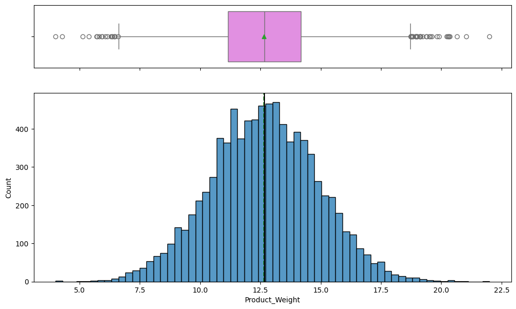

```python
hist_boxplot(data, 'Product_Weight')
```

**Observations**

- The product weight is pretty much normally distributed with a mean and median slightly over 12.5

**Product_Allocated_Area**

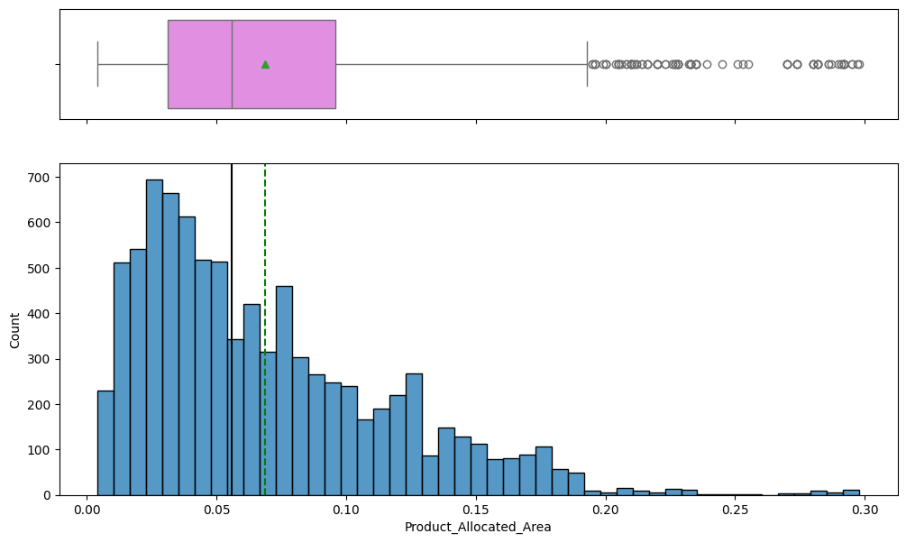

```python
hist_boxplot(data, 'Product_Allocated_Area')
```

**Observation:**

- The Product_Allocated_Area distribution is right skewed with the median around 0.05.
- The boxplot shows us that there are a select number of products that are outliers which have much higher than the average Allocated Area.

**Product_MRP**

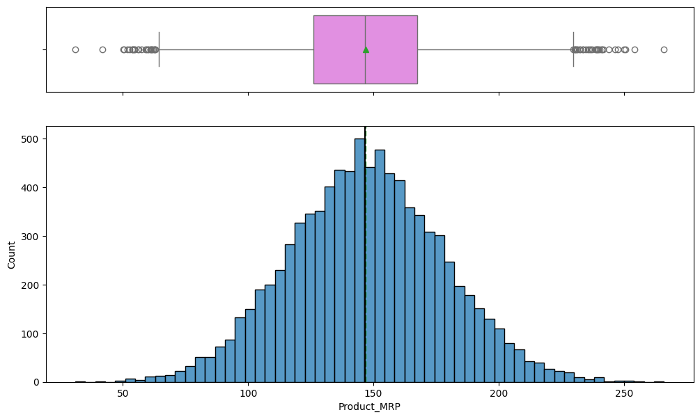

```python
hist_boxplot(data, 'Product_MRP')
```

**Observation:**

**Product_Store_Sales_Total**

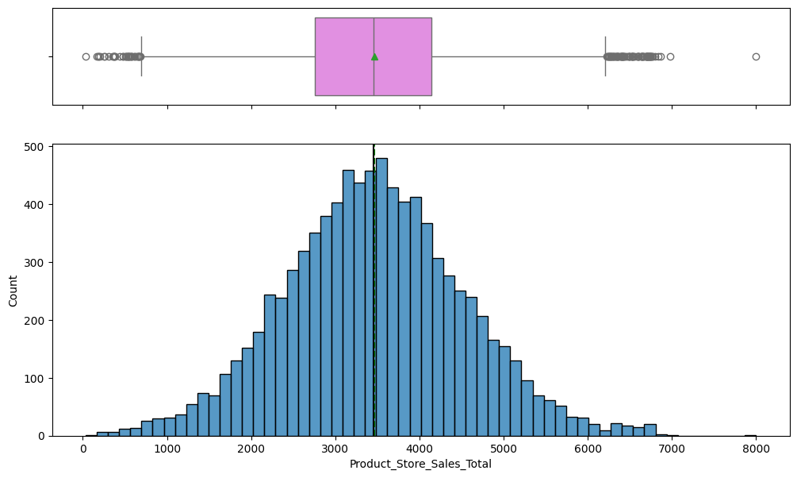

```python
hist_boxplot(data, 'Product_Store_Sales_Total')
```

**Observations:**

- The revenue generated from each product at a particular store is normally distributed with a mean and median lying around 3,500.

```python
# Function to create labeled barplots

def labeled_barplot(data, feature, perc = False, n = None):
  '''
  Barplot with percentage at the top

  data: dataframe
  feature: dataframe column/variable
  perc: display percentages instead of count (default = False)
  n: displays the top n category levels (default is None, ie. display all levels)
  '''

  total = len(data[feature])                # Length of the column
  count = data[feature].nunique()
  if n is None:
    plt.figure(figsize = (count +1, 5))
  else:
    plt.figure(figsize = (n + 1, 5))

  plt.xticks(rotation = 90, fontsize = 15)
  ax = sns.countplot(
      data = data,
      x = feature,
      palette = 'gnuplot',
      order = data[feature].value_counts().index[:n].sort_values(),
  )

  for p in ax.patches:
    if perc == True:
      label = "{:.1f}%".format(
          100 *p.get_height() / total
      )                                   # Percentage of each class of the category
    else:
      label = p.get_height()              # Count of each level of the category

    x = p.get_x() + p.get_width() / 2     # Width of the plot
    y = p.get_height()                    # Height of the plot

    ax.annotate(
        label,
        (x, y),
        ha = 'center',
        va = 'center',
        size = 12,
        xytext = (0, 5),
        textcoords = 'offset points',
    )                                     # Annotate the percentage
  plt.show()                            # Shows the plot
```

**Product_Sugar_Content**

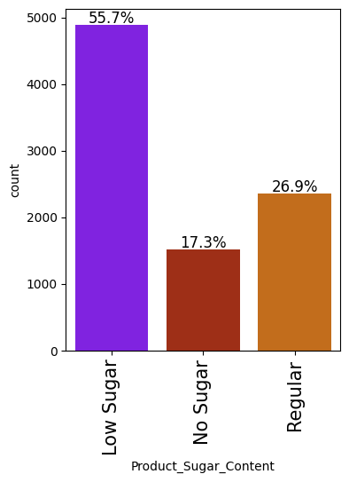

```python
labeled_barplot(data, 'Product_Sugar_Content', perc = True)
```

**Observations:**

- About 56% of the products in the store are 'Low Sugar' content, followed by 'Regular' and 'No Sugar'.

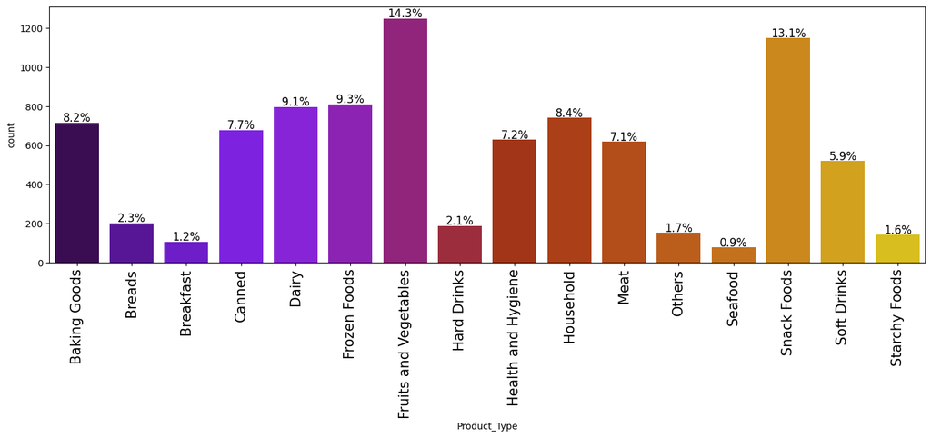

```python
labeled_barplot(data, 'Product_Type', perc = True)
```

**Observations:**

- Fruits and Vegetables (14%) and Snack Foods (13%) have been purchased the most fom all of the stores combined.
- Seafood (1%) has been bought the least.
- Other popular/higher selling items are Frozen Foods (9%), Dairy (9%), Household (8%), Baking Goods (8%), Canned (7%) and Meat (7%).

**Store ID**

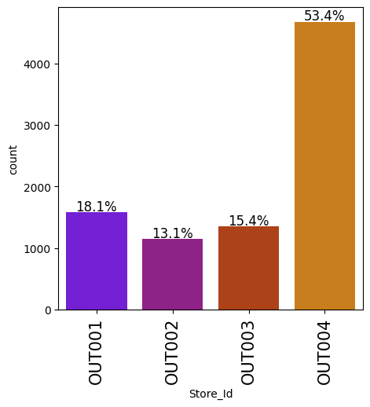

```python
labeled_barplot(data, 'Store_Id', perc = True)
```

**Observations:**

- About 53% of the total products sold are from store OUT004 alone, which is a greater precentage than the remaining 3 stores combined.
- OUT002 has the lowest sales, which makes sense given that it is a food mart and likely smaller than the other outlets.

**Store_Size**

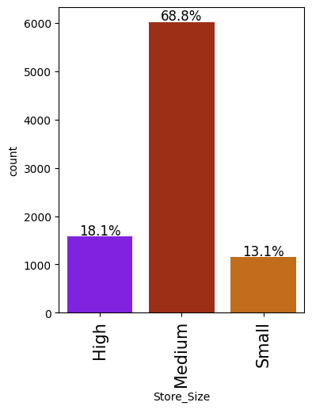

```python
labeled_barplot(data, 'Store_Size', perc = True)
```

**Observations:**

- The majority (almost 69%) of products are sold at a medium sized outlet.
- The remaining products sold (at small and large stores) are more or less the same.

**Store_Location_City_Type**

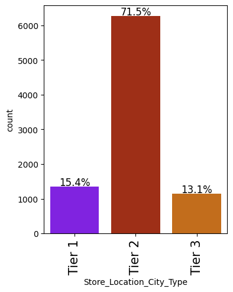

```python
labeled_barplot(data, 'Store_Location_City_Type', perc = True)
```

**Observations:**

- Almost 72% of products sold are from stores located in Tier 2 cities.
- The remaining products (sold in Tier 1 and Tier 3 cities) are nearly the same.

**Store_Type**

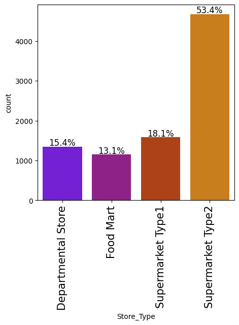

```python
labeled_barplot(data, 'Store_Type', perc = True)
```

**Observations**

- Products sold by Store_Type identically match the numbers of products sold by Store_Id.
- This matches our earlier observation that each of the four stores is a different Store_Type.

## **Bivariate Analysis**

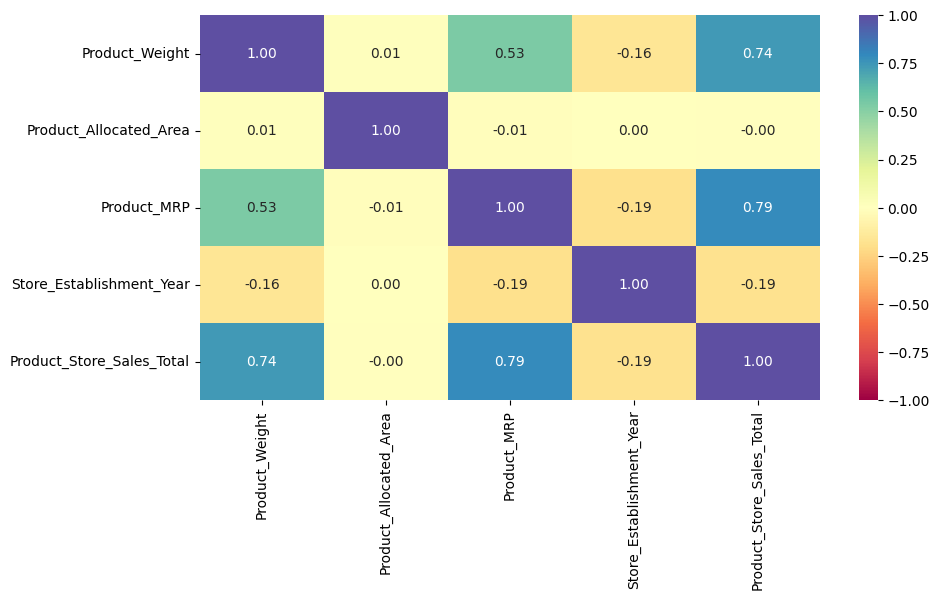

```python
# Creating a list of numerical column names
num_cols = data.select_dtypes(include = np.number).columns.tolist()

# Plotting a heatmap of numeric variable correlation
plt.figure(figsize = (10, 5))
sns.heatmap(
    data[num_cols].corr(), annot = True, vmin = -1, vmax = 1, fmt = '.2f', cmap = 'Spectral'
)
plt.show()
```

**Observations:**

**Checking the distribution of the target variable with each numeric column**

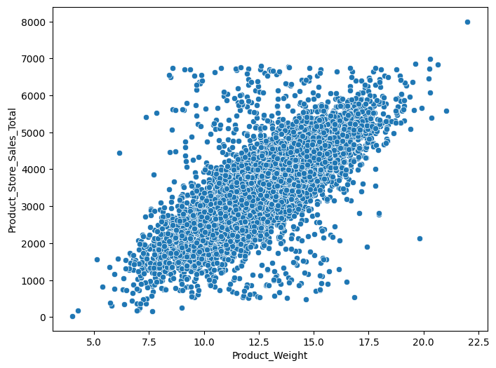

```python
plt.figure(figsize = (8, 6))
sns.scatterplot(x = data.Product_Weight, y = data.Product_Store_Sales_Total)
plt.show()
```

**Observations:**

- As we observed in our correlation heatmap, Product_Weight and our target variable have a strong positive linear correlation.

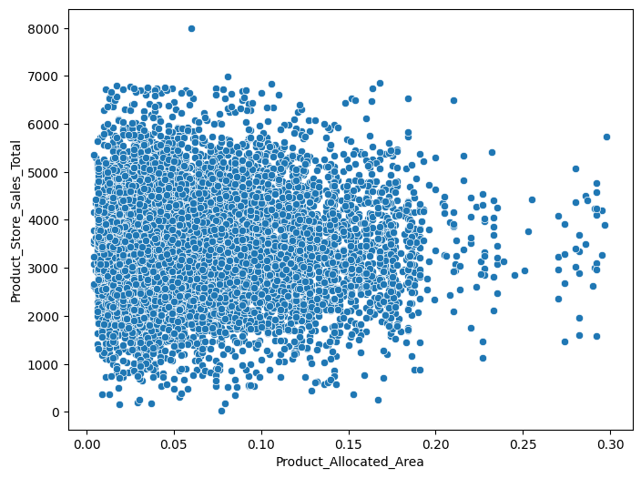

```python
plt.figure(figsize = (8, 6))
sns.scatterplot(x = data.Product_Allocated_Area, y = data.Product_Store_Sales_Total)
plt.show()
```

**Observations:**

- Product_Allocated_Area and our target variable seem to have no relationship.

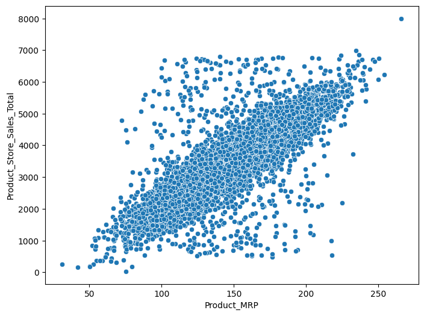

```python
plt.figure(figsize = (8, 6))
sns.scatterplot(x = data.Product_MRP, y = data.Product_Store_Sales_Total)
plt.show()
```

**Observations:**

- Once again, as observed in our correlation heatmap, Product_MRP and Product_Sales_Store_Total are hightly positively correlated.

**Examining which product type generates the most revenue for the company**

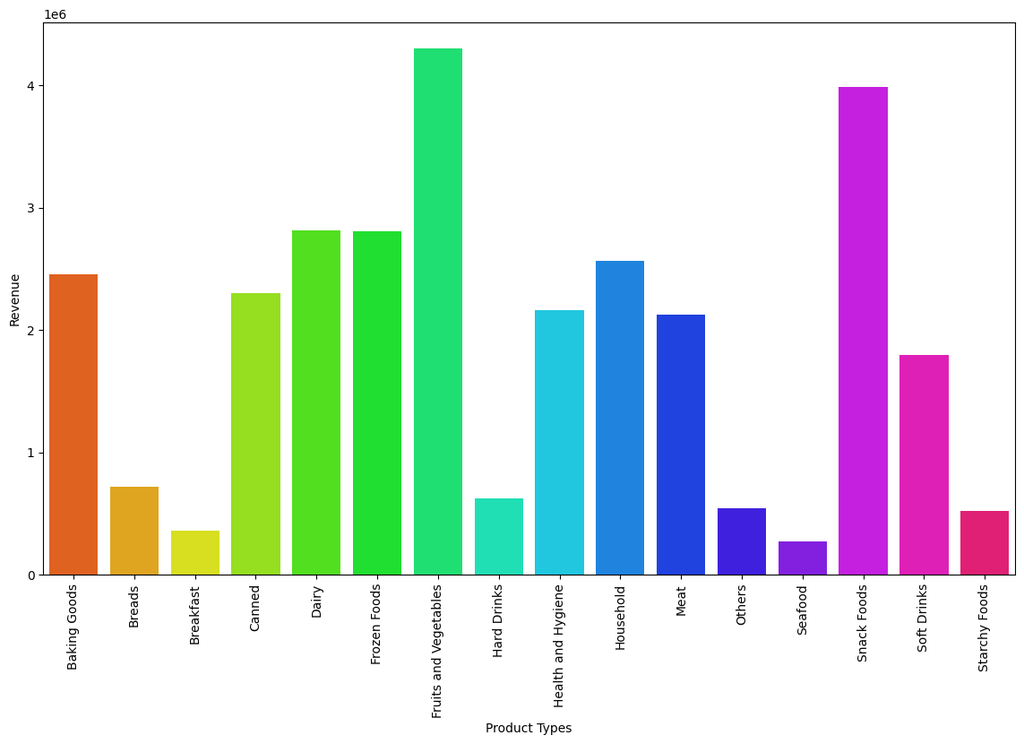

```python
df_revenue1 = data.groupby(['Product_Type'], as_index = False)['Product_Store_Sales_Total'].sum()
plt.figure(figsize = (14, 8))
plt.xticks(rotation = 90)
a = sns.barplot(x = df_revenue1.Product_Type, y = df_revenue1.Product_Store_Sales_Total, palette = 'hsv')
a.set_xlabel('Product Types')
a.set_ylabel('Revenue');
```

**Observations:**

- Fruits and Vegetables, and Snack Foods are the biggest contributors to the revenue of of the company.
- Seafood is the lowest contributor to revenue.
- These total revenue numbers quite closely match the total numbers of individual items sold by product type. This makes sense; unless one particular Product Type had an MRP what was a significant outlier, these numbers should line up quite closely.

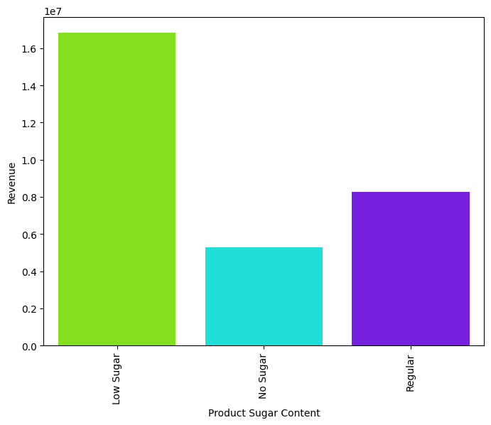

```python
df_revenue2 = data.groupby(['Product_Sugar_Content'], as_index = False)['Product_Store_Sales_Total'].sum()
plt.figure(figsize = (8, 6))
plt.xticks(rotation = 90)
a = sns.barplot(x = df_revenue2.Product_Sugar_Content, y = df_revenue2.Product_Store_Sales_Total, palette = 'hsv')
a.set_xlabel('Product Sugar Content')
a.set_ylabel('Revenue');
```

**Observations:**

- Low sugar content products are the biggest contributors to the revenue of the company.
- No sugar content products contribute the least.

**Examining which store type and locations generate the most revenue**

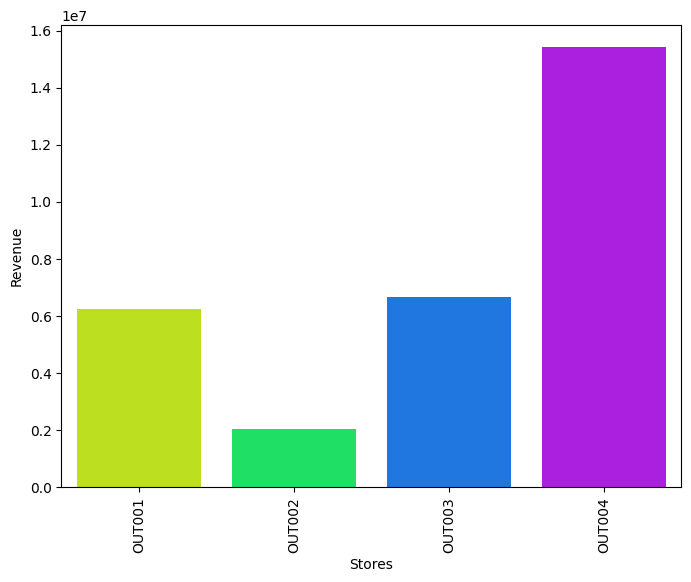

```python
df_store_revenue = data.groupby(['Store_Id'], as_index = False)['Product_Store_Sales_Total'].sum()
plt.figure(figsize = (8, 6))
plt.xticks(rotation = 90)
a = sns.barplot(x = df_store_revenue.Store_Id, y = df_store_revenue.Product_Store_Sales_Total, palette = 'hsv')
a.set_xlabel('Stores')
a.set_ylabel('Revenue');
```

**Observations**

- OUT004 is contributing the most to revenue, as expected given the high percentage of total products sold.
- OUT002 is contributing the least, at 1/3 the revenue of the next highest outlet. Given that OUT002 is a Food Mart this makes sense - most items sold are likely low price point/low margin items.

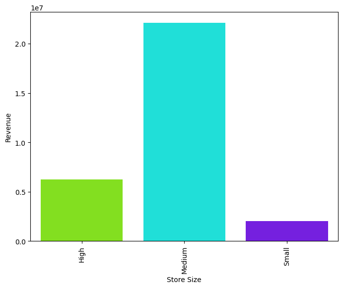

```python
df_revenue3 = data.groupby(['Store_Size'], as_index = False)['Product_Store_Sales_Total'].sum()
plt.figure(figsize = (8, 6))
plt.xticks(rotation = 90)
a = sns.barplot(x = df_revenue3.Store_Size, y = df_revenue3.Product_Store_Sales_Total, palette = 'hsv')
a.set_xlabel('Store Size')
a.set_ylabel('Revenue');
```

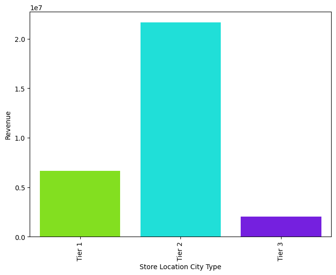

```python
df_revenue4 = data.groupby(['Store_Location_City_Type'], as_index = False)['Product_Store_Sales_Total'].sum()
plt.figure(figsize = (8, 6))
plt.xticks(rotation = 90)
a = sns.barplot(x = df_revenue4.Store_Location_City_Type, y = df_revenue4.Product_Store_Sales_Total, palette = 'hsv')
a.set_xlabel('Store Location City Type')
a.set_ylabel('Revenue');
```

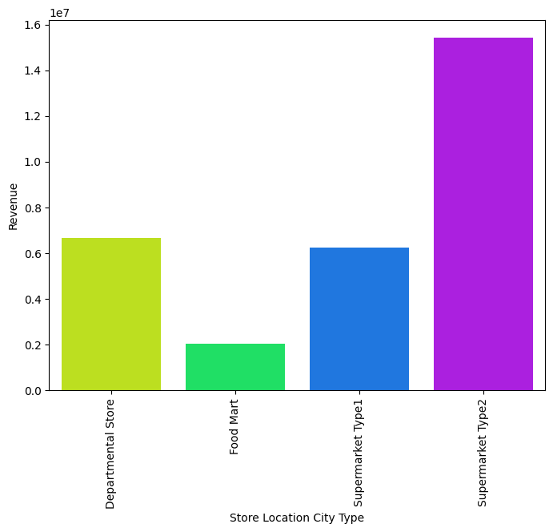

```python
df_revenue5 = data.groupby(['Store_Type'], as_index = False)['Product_Store_Sales_Total'].sum()
plt.figure(figsize = (8, 6))
plt.xticks(rotation = 90)
a = sns.barplot(x = df_revenue5.Store_Type, y = df_revenue5.Product_Store_Sales_Total, palette = 'hsv')
a.set_xlabel('Store Location City Type')
a.set_ylabel('Revenue');
```

**Checking the distribution of the target variable against other categorical columns**

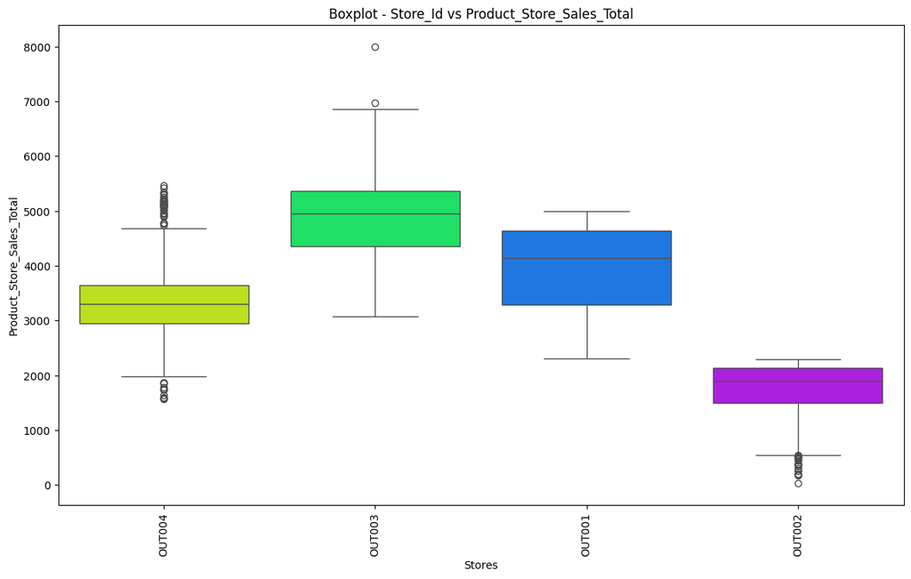

```python
plt.figure(figsize = (14, 8))
sns.boxplot(data = data, x = data['Store_Id'], y = data['Product_Store_Sales_Total'], palette = 'hsv')
plt.xticks(rotation = 90)
plt.title('Boxplot - Store_Id vs Product_Store_Sales_Total')
plt.xlabel('Stores')
plt.ylabel('Product_Store_Sales_Total');
```

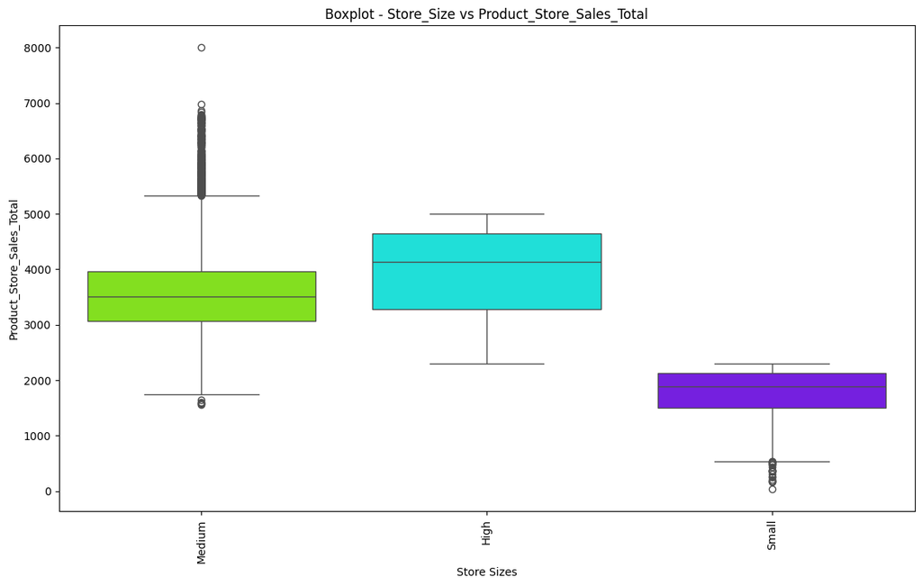

```python
plt.figure(figsize = (14, 8))
sns.boxplot(data = data, x = data['Store_Size'], y = data['Product_Store_Sales_Total'], palette = 'hsv')
plt.xticks(rotation = 90)
plt.title('Boxplot - Store_Size vs Product_Store_Sales_Total')
plt.xlabel('Store Sizes')
plt.ylabel('Product_Store_Sales_Total');
```

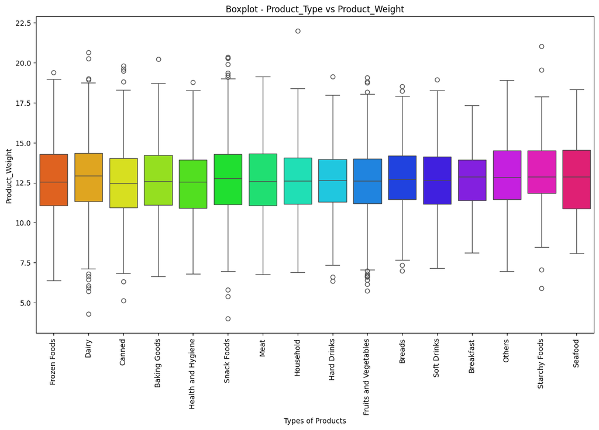

```python
plt.figure(figsize = (14, 8))
sns.boxplot(data = data, x = data['Product_Type'], y = data['Product_Weight'], palette = 'hsv')
plt.xticks(rotation = 90)
plt.title('Boxplot - Product_Type vs Product_Weight')
plt.xlabel('Types of Products')
plt.ylabel('Product_Weight');
```

**Observation:**

**Checking for a relationship between weight of product and its sugar content.**

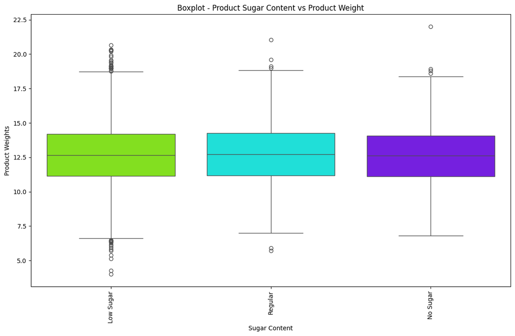

```python
plt.figure(figsize = (14, 8))
sns.boxplot(data = data, x = data['Product_Sugar_Content'], y = data['Product_Weight'], palette = 'hsv')
plt.xticks(rotation = 90)
plt.title('Boxplot - Product Sugar Content vs Product Weight')
plt.xlabel('Sugar Content')
plt.ylabel('Product Weights');
```

**Observations:**

- There does not seem to be any significant relationship between Product_Sugar_Content and Product_Weight. The median and IQR of Product_Weight grouped by Product_Sugar_Content are nearly identical.

**Analyzing the sugar content across different product types.**

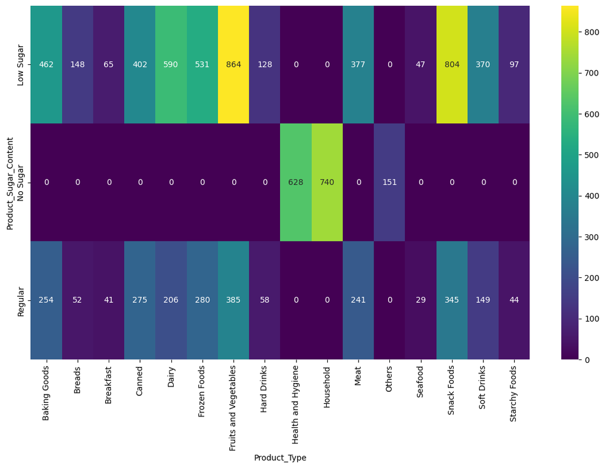

```python
plt.figure(figsize = (14 , 8))
sns.heatmap(
    pd.crosstab(data['Product_Sugar_Content'], data['Product_Type']),
    annot = True,
    fmt = 'g',
    cmap = 'viridis')

plt.ylabel('Product_Sugar_Content')
plt.xlabel('Product_Type');
```

**Observations:**

- Health and Hygiene, Household, and Others are the only categories with entries for "No Sugar". Conversely, these categoies do not have any items with regular or low sugar.
- Fruits and Vegetables have a very high percentage of "Low Sugar", which makes sense as vegetables in particular are naturally low sugar foods.
- Interestingly, there are no "No Sugar" items in Soft Drinks or Snack Foods, categories which often have No Sugar options (eg. Coke Zero, etc..).

**Checking how many items of each product type have been sold in each store.**

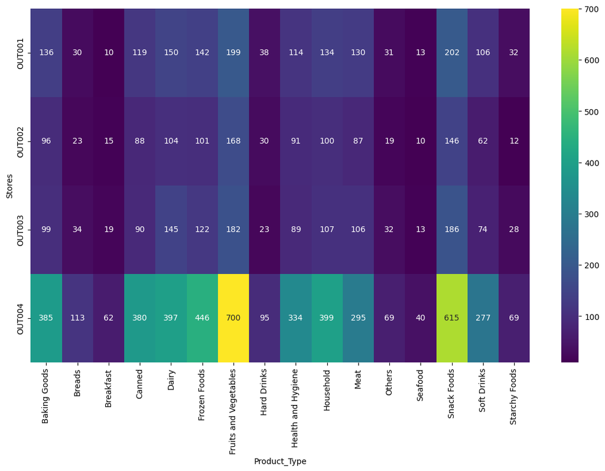

```python
plt.figure(figsize = (14 , 8))
sns.heatmap(
    pd.crosstab(data['Store_Id'], data['Product_Type']),
    annot = True,
    fmt = 'g',
    cmap = 'viridis')

plt.ylabel('Stores')
plt.xlabel('Product_Type');
```

**Observations:**

**Checking product price across different product categories.**

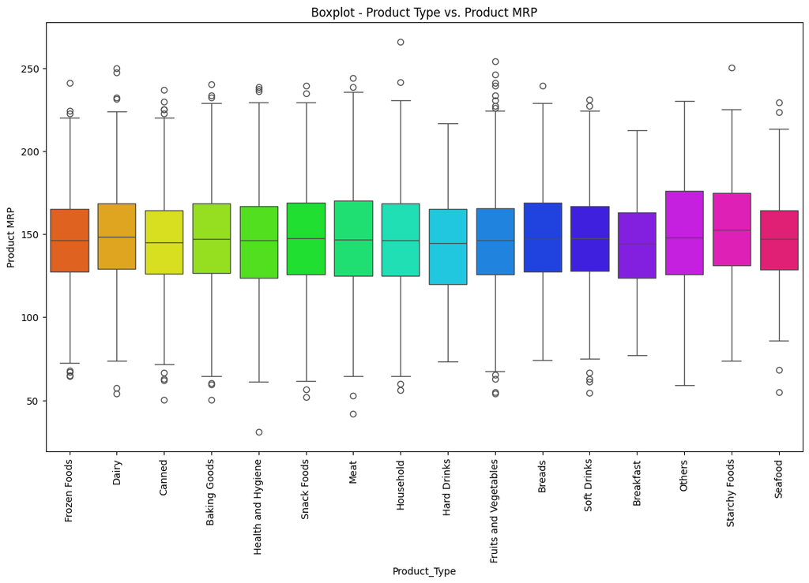

```python
plt.figure(figsize = (14, 8))
sns.boxplot(data = data, x = data['Product_Type'], y = data['Product_MRP'], palette = 'hsv')
plt.xticks(rotation = 90)
plt.title('Boxplot - Product Type vs. Product MRP')
plt.ylabel('Product MRP');
```

**Observations:**

**Checking Product MRP's across different Stores**

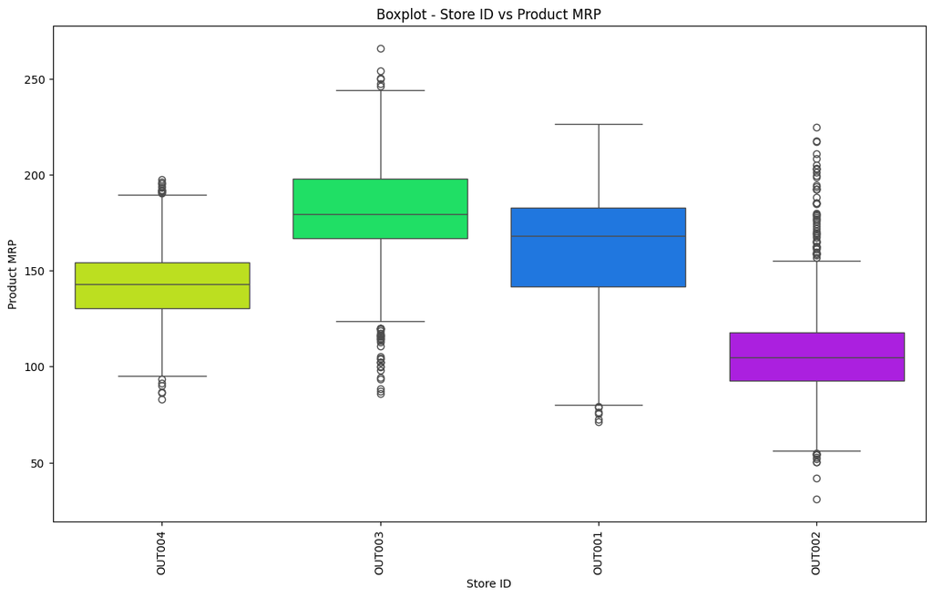

```python
plt.figure(figsize = (14, 8))
sns.boxplot(data = data, x = data['Store_Id'], y = data['Product_MRP'], palette = 'hsv')
plt.xticks(rotation = 90)
plt.title('Boxplot - Store ID vs Product MRP')
plt.xlabel('Store ID')
plt.ylabel('Product MRP');
```

**Observations:**

- OUT004, a Supermarket Type 2, has the smallest range of Product MRP's. This is interesting given it has the highest number of products sold.
- OUT003 has the most expensive items, which makes sense as it is a departmental store.
- OUT002 has the least expensive items, which again correlates to its store type of a Food Mart.

**Looking into each store on their own**

```python
data.groupby(by=["Store_Id"])["Product_Store_Sales_Total"].sum()
```

```
Store_Id
OUT001     6223113.18
OUT002     2030909.72
OUT003     6673457.57
OUT004    15427583.43
Name: Product_Store_Sales_Total, dtype: float64
```

```python
data.loc[data['Store_Id'] == 'OUT001'].describe(include = 'all').T
```

|  | count | unique | top | freq | mean | std | min | 25% | 50% | 75% | max |
| --- | --- | --- | --- | --- | --- | --- | --- | --- | --- | --- | --- |
| Product_Weight | 1586.0 | NaN | NaN | NaN | 13.458865 | 2.064975 | 6.16 | 12.0525 | 13.96 | 14.95 | 17.97 |
| Product_Sugar_Content | 1586 | 3 | Low Sugar | 845 | NaN | NaN | NaN | NaN | NaN | NaN | NaN |
| Product_Allocated_Area | 1586.0 | NaN | NaN | NaN | 0.068768 | 0.047131 | 0.004 | 0.033 | 0.0565 | 0.094 | 0.295 |
| Product_Type | 1586 | 16 | Snack Foods | 202 | NaN | NaN | NaN | NaN | NaN | NaN | NaN |
| Product_MRP | 1586.0 | NaN | NaN | NaN | 160.514054 | 30.359059 | 71.35 | 141.72 | 168.32 | 182.9375 | 226.59 |
| Store_Id | 1586 | 1 | OUT001 | 1586 | NaN | NaN | NaN | NaN | NaN | NaN | NaN |
| Store_Establishment_Year | 1586.0 | NaN | NaN | NaN | 1987.0 | 0.0 | 1987.0 | 1987.0 | 1987.0 | 1987.0 | 1987.0 |
| Store_Size | 1586 | 1 | High | 1586 | NaN | NaN | NaN | NaN | NaN | NaN | NaN |
| Store_Location_City_Type | 1586 | 1 | Tier 2 | 1586 | NaN | NaN | NaN | NaN | NaN | NaN | NaN |
| Store_Type | 1586 | 1 | Supermarket Type1 | 1586 | NaN | NaN | NaN | NaN | NaN | NaN | NaN |
| Product_Store_Sales_Total | 1586.0 | NaN | NaN | NaN | 3923.778802 | 904.62901 | 2300.56 | 3285.51 | 4139.645 | 4639.4 | 4997.63 |
| Product_Id_char | 1586 | 3 | FD | 1163 | NaN | NaN | NaN | NaN | NaN | NaN | NaN |

**Observations:**

- OUT001 is a Supermarket Type 1 store, located in a Tier 2 city, and is a high sized store. It was established in 1987.
- Its products have an MRP range from 71 to 227.
- Snack Foods have been sold the highest number of times at the store, and Low Sugar products are most commonly sold.

```python
data.loc[data['Store_Id'] == 'OUT001', 'Product_Store_Sales_Total'].sum()
```

```
6223113.18
```

**The store's total revenue from this dataset is 6,223,113.00.**

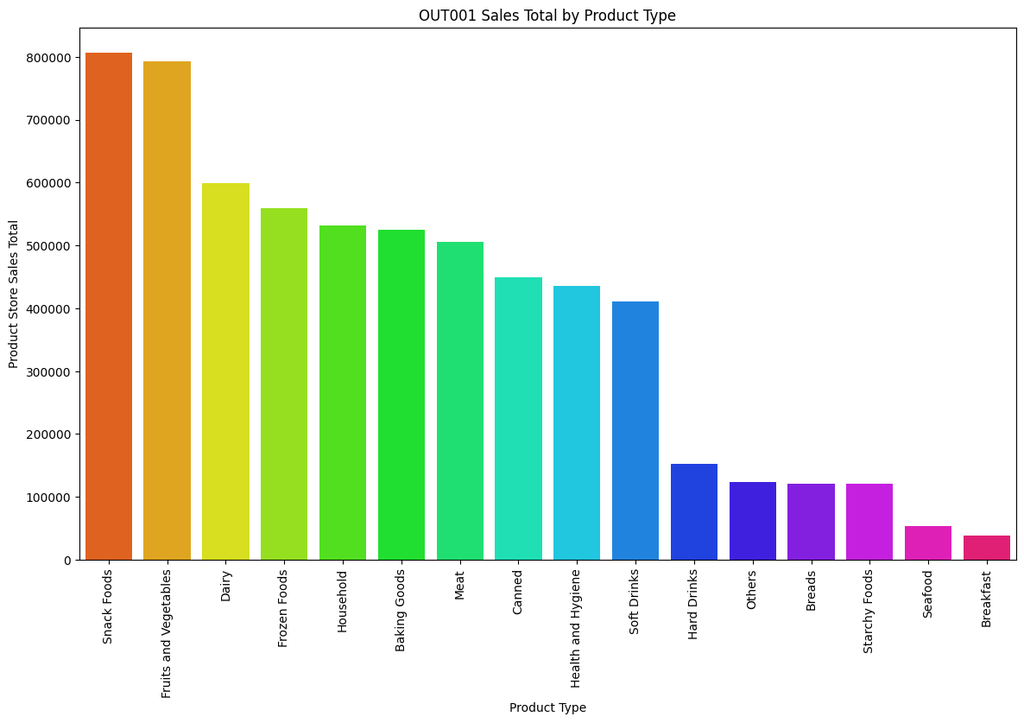

```python
df_OUT001 = (
    data.loc[data['Store_Id'] == 'OUT001']
    .groupby(by = ['Product_Type'], as_index = False)['Product_Store_Sales_Total']
    .sum()
)
df_OUT001.sort_values(by = 'Product_Store_Sales_Total', inplace = True, ascending = False)
plt.figure(figsize = (14, 8))
plt.xticks(rotation = 90)
plt.xlabel('Product Type')
plt.ylabel('Product Store Sales Total')
plt.title('OUT001 Sales Total by Product Type')
sns.barplot(x = df_OUT001['Product_Type'], y = df_OUT001['Product_Store_Sales_Total'], palette = 'hsv');
```

**Observations:**

- Snack Food and Fruits and Vegetables are the highest revenue drivers for this particular store, at almost 800,000. Dairy, Frozen Foods and Household are the next highest categories.
- Seafood, Breakfast and Startchy Foods are the weakest revenue drivers for the store.

**OUT002**

```python
data.loc[data['Store_Id'] == 'OUT002'].describe(include = 'all').T
```

|  | count | unique | top | freq | mean | std | min | 25% | 50% | 75% | max |
| --- | --- | --- | --- | --- | --- | --- | --- | --- | --- | --- | --- |
| Product_Weight | 1152.0 | NaN | NaN | NaN | 9.911241 | 1.799846 | 4.0 | 8.7675 | 9.795 | 10.89 | 19.82 |
| Product_Sugar_Content | 1152 | 3 | Low Sugar | 658 | NaN | NaN | NaN | NaN | NaN | NaN | NaN |
| Product_Allocated_Area | 1152.0 | NaN | NaN | NaN | 0.067747 | 0.047567 | 0.006 | 0.031 | 0.0545 | 0.09525 | 0.292 |
| Product_Type | 1152 | 16 | Fruits and Vegetables | 168 | NaN | NaN | NaN | NaN | NaN | NaN | NaN |
| Product_MRP | 1152.0 | NaN | NaN | NaN | 107.080634 | 24.912333 | 31.0 | 92.8275 | 104.675 | 117.8175 | 224.93 |
| Store_Id | 1152 | 1 | OUT002 | 1152 | NaN | NaN | NaN | NaN | NaN | NaN | NaN |
| Store_Establishment_Year | 1152.0 | NaN | NaN | NaN | 1998.0 | 0.0 | 1998.0 | 1998.0 | 1998.0 | 1998.0 | 1998.0 |
| Store_Size | 1152 | 1 | Small | 1152 | NaN | NaN | NaN | NaN | NaN | NaN | NaN |
| Store_Location_City_Type | 1152 | 1 | Tier 3 | 1152 | NaN | NaN | NaN | NaN | NaN | NaN | NaN |
| Store_Type | 1152 | 1 | Food Mart | 1152 | NaN | NaN | NaN | NaN | NaN | NaN | NaN |
| Product_Store_Sales_Total | 1152.0 | NaN | NaN | NaN | 1762.942465 | 462.862431 | 33.0 | 1495.4725 | 1889.495 | 2133.6225 | 2299.63 |
| Product_Id_char | 1152 | 3 | FD | 850 | NaN | NaN | NaN | NaN | NaN | NaN | NaN |

**Observations:**

- OUT002 is a Food Mart (small size) in a Tier 3 city, establisted in 1998.
- OUT002 product MRP's range from 31 to 225.
- Fruits and Vegetables are the most commonly sold items.

```python
data.loc[data['Store_Id'] == 'OUT002', 'Product_Store_Sales_Total'].sum()
```

```
2030909.72
```

**OUT002 has generated a total revenue of 2,030,910 from the sales in this dataset.**

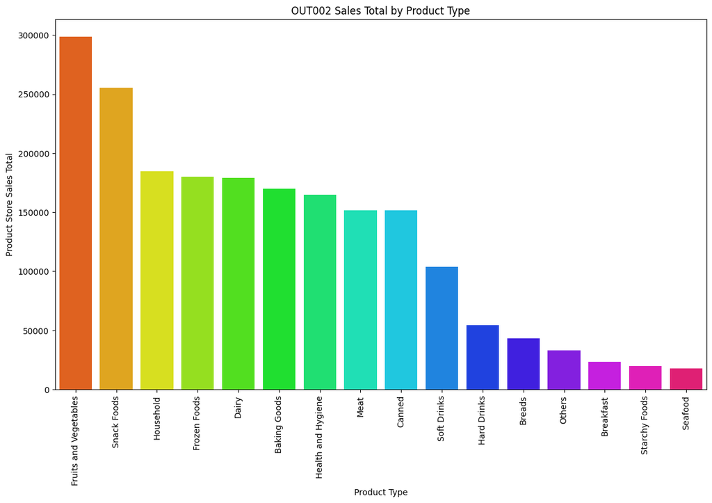

```python
df_OUT002 = (
    data.loc[data['Store_Id'] == 'OUT002']
    .groupby(by = ['Product_Type'], as_index = False)['Product_Store_Sales_Total']
    .sum()
)
df_OUT002.sort_values(by = 'Product_Store_Sales_Total', inplace = True, ascending = False)
plt.figure(figsize = (14, 8))
plt.xticks(rotation = 90)
plt.xlabel('Product Type')
plt.ylabel('Product Store Sales Total')
plt.title('OUT002 Sales Total by Product Type')
sns.barplot(x = df_OUT002['Product_Type'], y = df_OUT002['Product_Store_Sales_Total'], palette = 'hsv');
```

**Observations:**

- The top revenue drivers are once again Fruits and Vegetables and Snack Foods (~300,000 - 250,0000). The lowest drivers are Seafood, Startchy Foods, and Breakfast items.

**OUT003**

```python
data.loc[data['Store_Id'] == 'OUT003'].describe(include = 'all').T
```

|  | count | unique | top | freq | mean | std | min | 25% | 50% | 75% | max |
| --- | --- | --- | --- | --- | --- | --- | --- | --- | --- | --- | --- |
| Product_Weight | 1349.0 | NaN | NaN | NaN | 15.103692 | 1.893531 | 7.35 | 14.02 | 15.18 | 16.35 | 22.0 |
| Product_Sugar_Content | 1349 | 3 | Low Sugar | 750 | NaN | NaN | NaN | NaN | NaN | NaN | NaN |
| Product_Allocated_Area | 1349.0 | NaN | NaN | NaN | 0.068637 | 0.048708 | 0.004 | 0.031 | 0.057 | 0.094 | 0.298 |
| Product_Type | 1349 | 16 | Snack Foods | 186 | NaN | NaN | NaN | NaN | NaN | NaN | NaN |
| Product_MRP | 1349.0 | NaN | NaN | NaN | 181.358725 | 24.796429 | 85.88 | 166.92 | 179.67 | 198.07 | 266.0 |
| Store_Id | 1349 | 1 | OUT003 | 1349 | NaN | NaN | NaN | NaN | NaN | NaN | NaN |
| Store_Establishment_Year | 1349.0 | NaN | NaN | NaN | 1999.0 | 0.0 | 1999.0 | 1999.0 | 1999.0 | 1999.0 | 1999.0 |
| Store_Size | 1349 | 1 | Medium | 1349 | NaN | NaN | NaN | NaN | NaN | NaN | NaN |
| Store_Location_City_Type | 1349 | 1 | Tier 1 | 1349 | NaN | NaN | NaN | NaN | NaN | NaN | NaN |
| Store_Type | 1349 | 1 | Departmental Store | 1349 | NaN | NaN | NaN | NaN | NaN | NaN | NaN |
| Product_Store_Sales_Total | 1349.0 | NaN | NaN | NaN | 4946.966323 | 677.539953 | 3069.24 | 4355.39 | 4958.29 | 5366.59 | 8000.0 |
| Product_Id_char | 1349 | 3 | FD | 1024 | NaN | NaN | NaN | NaN | NaN | NaN | NaN |

**Observation:**

```python
data.loc[data['Store_Id'] == 'OUT003', 'Product_Store_Sales_Total'].sum()
```

```
6673457.57
```

**OUT003 has generated 6,673,457.57 in revenue from products in this dataset.**

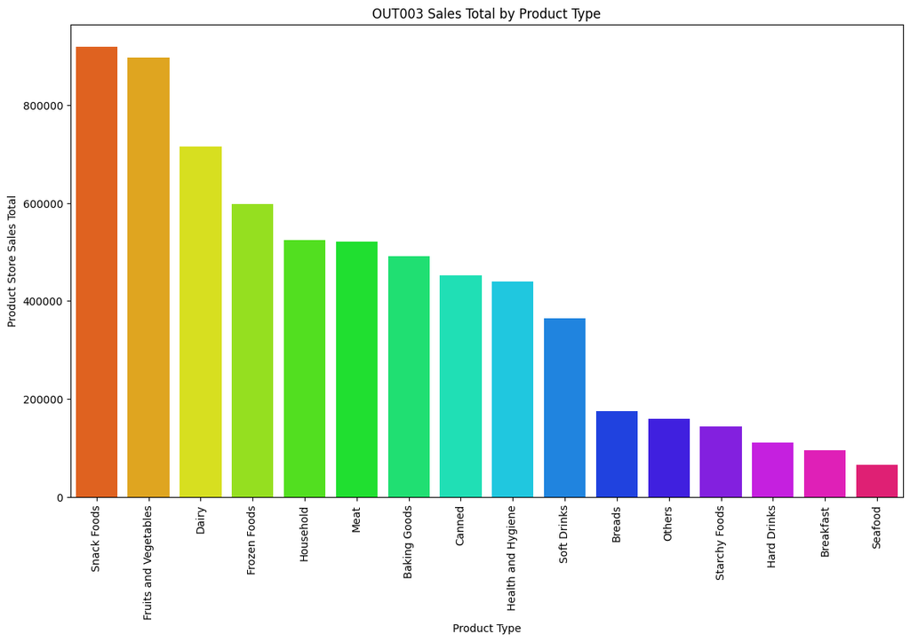

```python
df_OUT003 = (
    data.loc[data['Store_Id'] == 'OUT003']
    .groupby(by = ['Product_Type'], as_index = False)['Product_Store_Sales_Total']
    .sum()
)
df_OUT003.sort_values(by = 'Product_Store_Sales_Total', inplace = True, ascending = False)
plt.figure(figsize = (14, 8))
plt.xticks(rotation = 90)
plt.xlabel('Product Type')
plt.ylabel('Product Store Sales Total')
plt.title('OUT003 Sales Total by Product Type')
sns.barplot(x = df_OUT003['Product_Type'], y = df_OUT003['Product_Store_Sales_Total'], palette = 'hsv');
```

**Observations:**

- OUT003 has similar top and bottom revenue drivers for the company, with its top drivers bringing in more than 800,000.

**OUT004**

```python
data.loc[data['Store_Id'] == 'OUT004'].describe(include = 'all').T
```

|  | count | unique | top | freq | mean | std | min | 25% | 50% | 75% | max |
| --- | --- | --- | --- | --- | --- | --- | --- | --- | --- | --- | --- |
| Product_Weight | 4676.0 | NaN | NaN | NaN | 12.349613 | 1.428199 | 7.34 | 11.37 | 12.37 | 13.3025 | 17.79 |
| Product_Sugar_Content | 4676 | 3 | Low Sugar | 2632 | NaN | NaN | NaN | NaN | NaN | NaN | NaN |
| Product_Allocated_Area | 4676.0 | NaN | NaN | NaN | 0.069092 | 0.048584 | 0.004 | 0.031 | 0.056 | 0.097 | 0.297 |
| Product_Type | 4676 | 16 | Fruits and Vegetables | 700 | NaN | NaN | NaN | NaN | NaN | NaN | NaN |
| Product_MRP | 4676.0 | NaN | NaN | NaN | 142.399709 | 17.513973 | 83.04 | 130.54 | 142.82 | 154.1925 | 197.66 |
| Store_Id | 4676 | 1 | OUT004 | 4676 | NaN | NaN | NaN | NaN | NaN | NaN | NaN |
| Store_Establishment_Year | 4676.0 | NaN | NaN | NaN | 2009.0 | 0.0 | 2009.0 | 2009.0 | 2009.0 | 2009.0 | 2009.0 |
| Store_Size | 4676 | 1 | Medium | 4676 | NaN | NaN | NaN | NaN | NaN | NaN | NaN |
| Store_Location_City_Type | 4676 | 1 | Tier 2 | 4676 | NaN | NaN | NaN | NaN | NaN | NaN | NaN |
| Store_Type | 4676 | 1 | Supermarket Type2 | 4676 | NaN | NaN | NaN | NaN | NaN | NaN | NaN |
| Product_Store_Sales_Total | 4676.0 | NaN | NaN | NaN | 3299.312111 | 468.271692 | 1561.06 | 2942.085 | 3304.18 | 3646.9075 | 5462.86 |
| Product_Id_char | 4676 | 3 | FD | 3502 | NaN | NaN | NaN | NaN | NaN | NaN | NaN |

**Observations:**

- OUT004 is a Supermarket Type 2, medium sized, located in a Tier 2 city. It was established in 2009, so it is the newest of all the stores.

```python
data.loc[data['Store_Id'] == 'OUT004', 'Product_Store_Sales_Total'].sum()
```

```
15427583.43
```

OUT004 has brought in 15,427,583.43 in revenue for the company, which is more than double the next highest store.

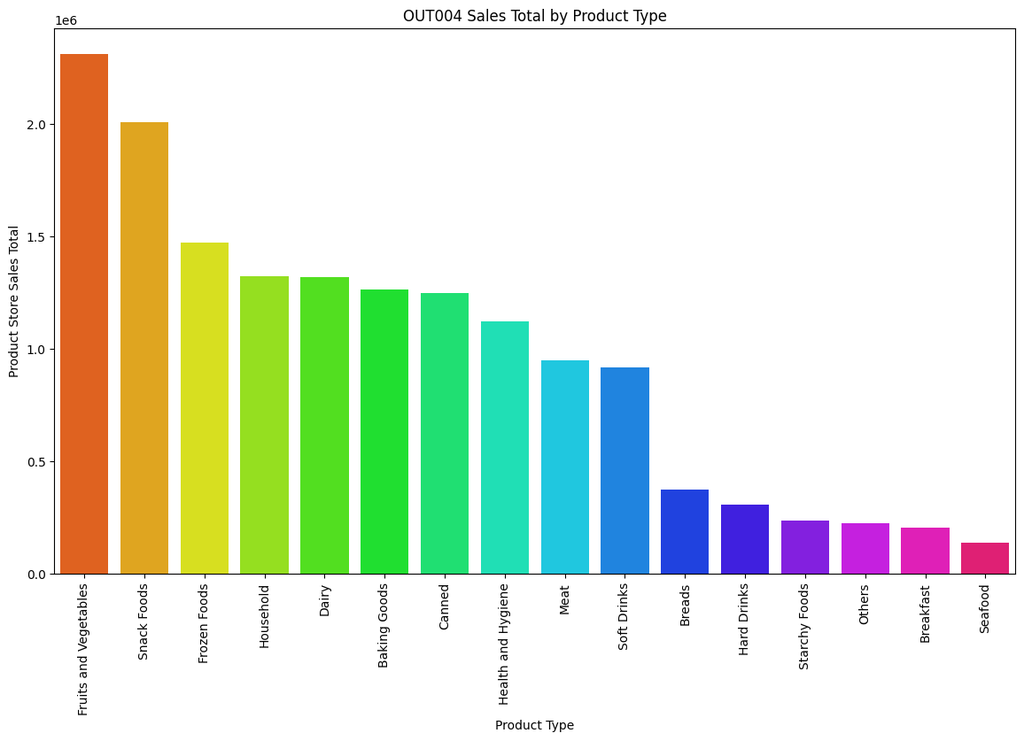

```python
df_OUT004 = (
    data.loc[data['Store_Id'] == 'OUT004']
    .groupby(by = ['Product_Type'], as_index = False)['Product_Store_Sales_Total']
    .sum()
)
df_OUT004.sort_values(by = 'Product_Store_Sales_Total', inplace = True, ascending = False)
plt.figure(figsize = (14, 8))
plt.xticks(rotation = 90)
plt.xlabel('Product Type')
plt.ylabel('Product Store Sales Total')
plt.title('OUT004 Sales Total by Product Type')
sns.barplot(x = df_OUT004['Product_Type'], y = df_OUT004['Product_Store_Sales_Total'], palette = 'hsv');
```

**Observations:**

- Fruits and Vegetables and Snack Foods are the highest revenue drivers at more than 2,000,000. Others, Breakfast and Seafood are the lowest drivers.